# Homework 1: Insights on Poverty_Chi-Hsuan Chang

February 4, 2016

**This homework is due Sunday February 14, 2016 at 11:59 PM. When complete, submit your code in the R Markdown file and the knitted HTML file on Canvas.**

# Background

This HW is based on Hans Rosling talks [New Insights on Poverty](https://www.ted.com/talks/hans_rosling_reveals_new_insights_on_poverty?language=en) and [The Best Stats You’ve Ever Seen](https://www.ted.com/talks/hans_rosling_shows_the_best_stats_you_ve_ever_seen).

1. Sri Lanka or Turkey
2. Poland or South Korea
3. Malaysia or Russia
4. Pakistan or Vietnam
5. Thailand or South Africa

Most people get them wrong. Why is this? In part it is due to our preconceived notion that the world is divided into two groups: the *Western world* versus the *third world*, characterized by “long life,small family” and “short life, large family” respectively. In this homework we will use data visualization to gain insights on this topic.

# Problem 1

The first step in our analysis is to download and organize the data. The necessary data to answer these question is available on the [gapminder](http://www.gapminder.org/data/) website.

## Problem 1.1

We will use the following datasets:

1. [Childhood mortality](http://spreadsheets.google.com/pub?key=0ArfEDsV3bBwCcGhBd2NOQVZ1eWowNVpSNjl1c3lRSWc&output=csv)
2. [Life expectancy](http://spreadsheets.google.com/pub?key=phAwcNAVuyj2tPLxKvvnNPA&output=csv)
3. [Fertility](http://spreadsheets.google.com/pub?key=phAwcNAVuyj0TAlJeCEzcGQ&output=csv)
4. [Population](http://spreadsheets.google.com/pub?key=phAwcNAVuyj0XOoBL_n5tAQ&output=csv)
5. [Total GDP](http://spreadsheets.google.com/pub?key=pyj6tScZqmEfI4sLVvEQtHw&output=csv)

Create five `tbl_df` table objects, one for each of the tables provided in the above files. Hints: Use the `read_csv` function. Because these are only temporary files, give them short names.

```r
setwd("~/Desktop/BIO260_1")
child_mortality <- read.csv("childhood_mortality.csv", check.names = F)
life_expectancy <- read.csv("life_expectancy.csv", check.names = F)
fertility <- read.csv("fertility.csv", check.names = F)
population <- read.csv("population.csv", check.names = F)
total_gdp <- read.csv("totalgdp.csv", check.names = F)
```

## Problem 1.2

Write a function called `my_func` that takes a table as an argument and returns the column name. For each of the five tables, what is the name of the column containing the country names? Print out the tables or look at them with `View` to determine the column.

```r
my_func <- function(x){
  return(colnames(x))
}
# Print out the column containing the country names:

my_func(child_mortality)[1]
```

```
## [1] "Under five mortality"
```

```r
my_func(life_expectancy)[1]
```

```
## [1] "Life expectancy with projections. Yellow is IHME"
```

```r
my_func(fertility)[1]
```

```
## [1] "Total fertility rate"
```

```r
my_func(population)[1]
```

```
## [1] "Total population"
```

```r
my_func(total_gdp)[1]
```

```
## [1] "GDP (constant 2000 US$)"
```

## Problem 1.3

In the previous problem we noted that gapminder is inconsistent in naming their country column. Fix this by assigning a common name to this column in the various tables.

```r
names(child_mortality)[1] = "country"
names(life_expectancy)[1] = "country"
names(fertility)[1] = "country"
names(population)[1] = "country"
names(total_gdp)[1] = "country"
```

## Problem 1.4

Notice that in these tables, years are represented by columns. We want to create a tidy dataset in which each row is a unit or observation and our 5 values of interest, including the year for that unit, are in the columns. The unit here is a country/year pair and each unit gets values:

Names of the five columns:

child_mortality

life_expectancy

fertility

population

total_gdp

```r
# Number of columns (number of year) in each dataset:
ncol(child_mortality)
```

```
## [1] 217
```

```r
ncol(life_expectancy)
```

```
## [1] 217
```

```r
ncol(fertility)
```

```
## [1] 217
```

```r
ncol(population)
```

```
## [1] 82
```

```r
ncol(total_gdp)
```

```
## [1] 53
```

```r
# Number of rows (number of countries) in each dataset:
nrow(child_mortality)
```

```
## [1] 275
```

```r
nrow(life_expectancy)
```

```
## [1] 260
```

```r
nrow(fertility)
```

```
## [1] 260
```

```r
nrow(population)
```

```
## [1] 275
```

```r
nrow(total_gdp)
```

```
## [1] 270
```

We call this the *long* format. Use the `gather` function from the `tidyr` package to create a new table for childhood mortality using the long format. Call the new columns `year` and `child_mortality`

```r
library(tidyr)
library(dplyr)
a = child_mortality %>%
  gather(country, child_mortality)
names(a)[2] = "year"
```

Now redefine the remaining tables in this way.

```r
b = life_expectancy %>%
  gather(country, life_expectancy)
c = fertility %>%
  gather(country, fertility)

fixpopulation <- function(x,i){
  y <- strsplit(as.character(x[,i]),",")
  ret <- sapply(y, function(z){
    if(length(z)>=4){as.numeric(z[1])*1000000000 + as.numeric(z[2])*1000000 + as.numeric(z[3])*1000 + as.numeric(z[4])}
    else if(length(z)>=3){as.numeric(z[1])*1000000 + as.numeric(z[2])*1000 + as.numeric(z[3])}
    else if(length(z)>=2){as.numeric(z[1])*1000 + as.numeric(z[2])}
    else{as.numeric(z[1])}
  })
  return(ret)
}

d = as.data.frame(matrix(0,nrow(population),ncol(population)))
for (j in 2:ncol(population)){
  d[,j] = fixpopulation(population,j)
  population[,j]=d[,j]
}

e = population %>%
  gather(country, population)

f = total_gdp %>%
  gather(country, total_gdp)

names(b)[2] = "year"
names(c)[2] = "year"
names(e)[2] = "year"
names(f)[2] = "year"
```

## Problem 1.5

Now we want to join all these files together. Make one consolidated table containing all the columns

```r
dat = full_join(a,b,by= c("country", "year")) %>%
  full_join(c,by= c("country", "year")) %>%
  full_join(e,by= c("country", "year")) %>%
  full_join(f,by= c("country", "year"))
```

## Problem 1.6

Add a column to the consolidated table containing the continent for each country. Hint: We have created a file that maps countries to continents [here](https://github.com/datasciencelabs/data/blob/master/homework_data/continent-info.tsv). Hint: Learn to use the `left_join` function.

```r
continent = read.csv("continent-info.csv", sep = "\t", header = F)
names(continent) = c("country","continent")
dat1 = left_join(dat, continent, by = "country")
```

# Problem 2

Report the child mortalilty rate in 2015 for these 5 pairs:

1. Sri Lanka or Turkey
2. Poland or South Korea
3. Malaysia or Russia
4. Pakistan or Vietnam
5. Thailand or South Africa

```r
dat1 %>%
  filter(country %in% c("Sri Lanka", "Turkey") & year==2015) %>%
  select(country, child_mortality)
```

```
##     country child_mortality
## 1 Sri Lanka             8.7
## 2    Turkey            13.5
```

```r
dat1 %>%
  filter(country %in% c("Poland", "South Korea") & year==2015) %>%
  select(country, child_mortality)
```

```
##       country child_mortality
## 1 South Korea             3.5
## 2      Poland             5.2
```

```r
dat1 %>%
  filter(country %in% c("Malaysia", "Russia") & year==2015) %>%
  select(country, child_mortality)
```

```
##    country child_mortality
## 1 Malaysia             8.2
## 2   Russia             9.6
```

```r
dat1 %>%
  filter(country %in% c("Pakistan", "Vietnam") & year==2015) %>%
  select(country, child_mortality)
```

```
##    country child_mortality
## 1 Pakistan            81.1
## 2  Vietnam            21.7
```

```r
dat1 %>%
  filter(country %in% c("Thailand", "South Africa") & year==2015) %>%
  select(country, child_mortality)
```

```
##        country child_mortality
## 1 South Africa            42.1
## 2     Thailand            12.3
```

# Problem 3

To examine if in fact there was a long-life-in-a-small-family and short-life-in-a-large-family dichotomy, we will visualize the average number of children per family (fertility) and the life expectancy for each country.

## Problem 3.1

Use `ggplot2` to create a plot of life expectancy versus fertiltiy for 1962 for Africa, Asia, Europe, and the Americas. Use color to denote continent and point size to denote population size:

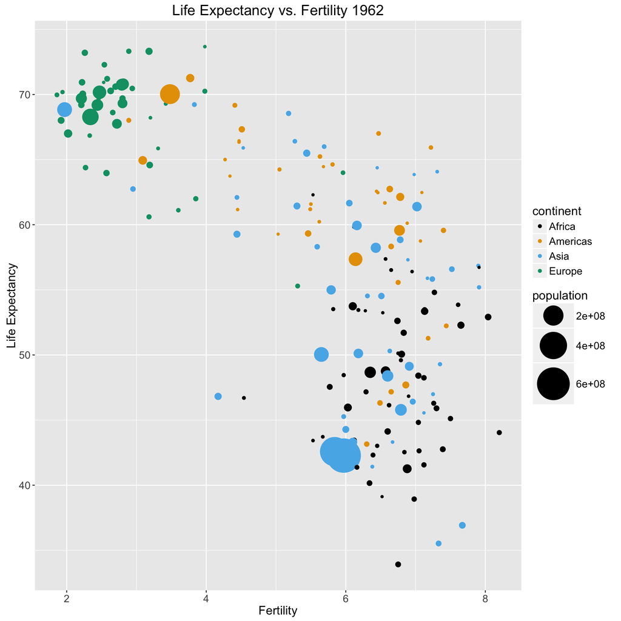

```r
library(ggplot2)
cbbPalette <- c("#000000", "#E69F00", "#56B4E9", "#009E73", "#F0E442", "#D55E00", "#0072B2", "#CC79A7")

p <- ggplot(filter(dat1, year == 1962 & continent != "Oceania"),aes(x = fertility, y = life_expectancy))
p + geom_point(aes(color = continent, size = population))+
    scale_size(range = c(1,18)) +theme(text = element_text(size=14),axis.text.x = element_text(size =12), axis.text.y = element_text(size =12),legend.text=element_text(size=12))+ggtitle("Life Expectancy vs. Fertility 1962")+labs(x = "Fertility", y = "Life Expectancy")+scale_colour_manual(values=cbbPalette)
```

Do you see a dichotomy? Explain.

Yes. Most countries in Asia and Africa had higher fertility and lower life expectancy while those in Europe had lower fertility and higher life expectancy in 1962. Countries in Americas were spread in between the two extremes. Since this is a cross-sectional data, it’s hard to tell if life expectancy affected fertility or the other way around. Possible explanations can be that African and Asian countries had lower life expectancy (which can due to higher children mortality/lower children survival, etc) so that was the reason why they want to have more children to make sure some of the descendants can live longer than the low threshold.

## Problem 3.2

Now we will annotate the plot to show different types of countries.

Learn about OECD and OPEC. Add a couple of columns to your consolidated tables containing a logical vector that tells if a country is OECD and OPEC respectively. It is ok to base membership on 2015.

```r
oecd = c("Australia",
"Austria",
"Belgium",
"Canada",
"Chile",
"Czech Republic",
"Denmark",
"Estonia",
"Finland",
"France",
"Germany",
"Greece",
"Hungary",
"Iceland",
"Ireland",
"Israel",
"Italy",
"Japan",
"South Korea",
"Luxembourg",
"Mexico",
"Netherlands",
"New Zealand",
"Norway",
"Poland",
"Portugal",
"Slovak Republic",
"Slovenia",
"Spain",
"Sweden",
"Switzerland",
"Turkey",
"United Kingdom",
"United States"
)
opec = c("Algeria",
"Angola",
"Ecuador",
"Indonesia",
"Iran",
"Iraq",
"Kuwait",
"Libya",
"Nigeria",
"Qatar",
"Saudi Arabia",
"United Arab Emirates",
"Venezuela")

dat1 = dat1 %>%
  mutate(OECD = FALSE) %>%
  mutate(OPEC = FALSE) %>%
  mutate(member = as.character(continent))
for (i in 1:length(dat1$country)){
  if (dat1$country[i] %in% oecd){
    dat1$OECD[i] <- TRUE
    dat1$member[i] <- "OECD"
  }
  else if (dat1$country[i] %in% opec){
    dat1$OPEC[i] <- TRUE
    dat1$member[i] <- "OPEC"
  }
  else if (dat1$continent[i] %in% c("Europe","Oceania"))
    dat1$member[i] <- "Others"
}
```

### Problem 3.3

Make the same plot as in Problem 3.1, but this time use color to annotate the OECD countries and OPEC countries. For countries that are not part of these two organization annotate if they are from Africa, Asia, or the Americas.

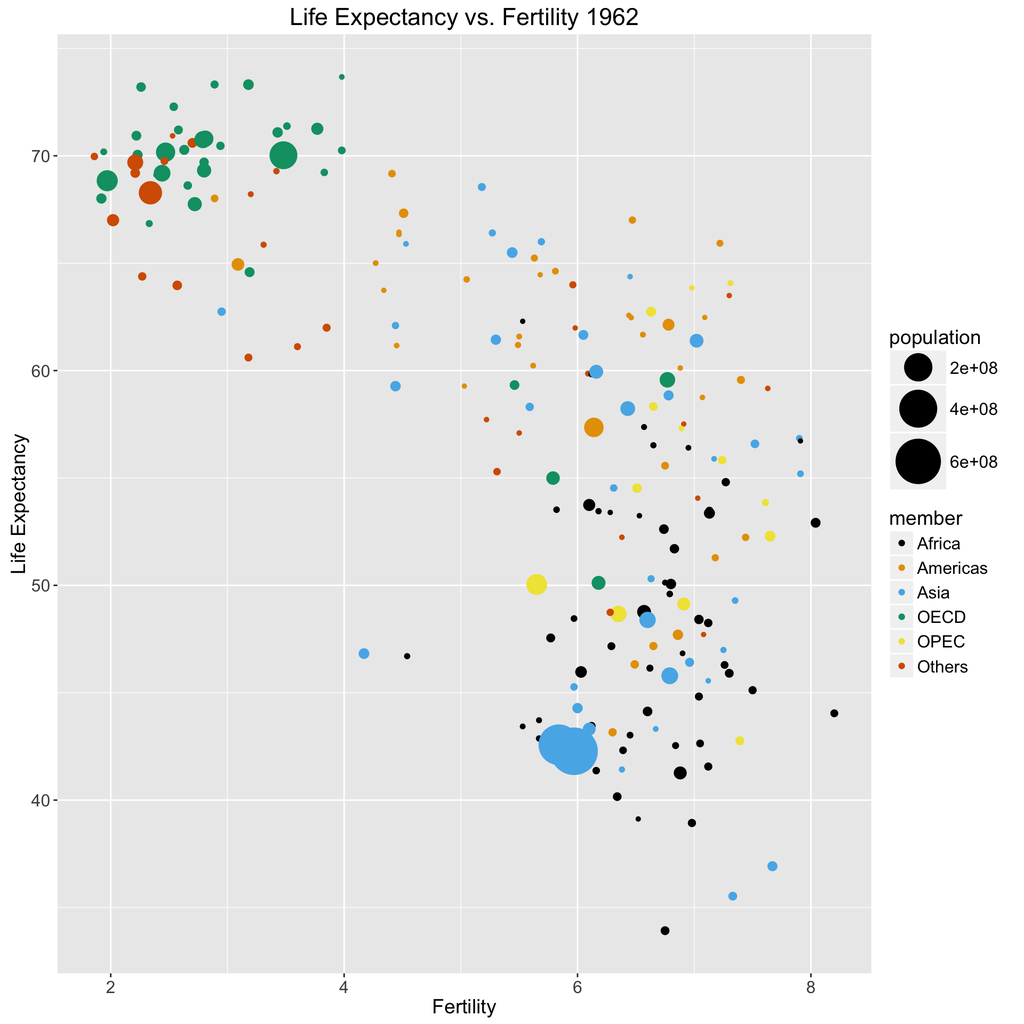

```r
library(ggrepel)
p <- ggplot(filter(dat1, year == 1962), aes(x = fertility, y = life_expectancy))
p<- p + geom_point(aes(color = member, size = population)) +
    scale_size(range = c(1,15))
p + geom_text_repel(data = filter(dat1, member =="none"),aes(label = continent))+theme(text = element_text(size=14),axis.text.x = element_text(size =12), axis.text.y = element_text(size =12),legend.text=element_text(size=12))+ggtitle("Life Expectancy vs. Fertility 1962")+labs(x = "Fertility", y = "Life Expectancy")+scale_colour_manual(values=cbbPalette)
```

```r
# Further analysis:
dat1 %>%
filter(OECD == TRUE & life_expectancy < 65 & fertility > 4 & year == 1962)
```

```
##       country year child_mortality life_expectancy fertility population
## 1       Chile 1962          142.30        59.32584      5.46    8054166
## 2 South Korea 1962          100.60        54.99436      5.79   26495107
## 3      Mexico 1962          133.78        59.56904      6.77   40649590
## 4      Turkey 1962          235.50        50.11556      6.18   28909985
##      total_gdp continent OECD  OPEC member
## 1  15418876405  Americas TRUE FALSE   OECD
## 2  31102566019      Asia TRUE FALSE   OECD
## 3 103696598044  Americas TRUE FALSE   OECD
## 4  47592935468      Asia TRUE FALSE   OECD
```

```r
# dat1 %>%
# filter(member == "Others"  & life_expectancy > 65 & fertility < 4 & year == 1962)
#
# dat1 %>%
# filter(OPEC == TRUE  & year == 1962)
```

How would you describe the dichotomy?

OECD countries are at the top left of this plot (less fertility and higher life expectancy) while the OPEC countries are around the bottom right of this plot (higher fertility and less life expectancy). It seems to me that developed countries have higher life expectancy and less fertility rate compared to other countries (especially developing countries in Africa and Asia). For OPEC countries, although they were at the bottom right corner, they had slightly higher life expectancy and less fertility rates compared to none-OPEC Asian/African countries. This may give us some hints that economic development is related to life expectancy and fertility rates (OPEC countries have oil and therefore may have higher GDP per capita; OPEC countries were observed to have higher life expectancy and lower fertility rates compared to other developing countries in Africa and Asia).

### Problem 3.4

Explore how this figure changes across time. Show us 4 figures that demonstrate how this figure changes through time.

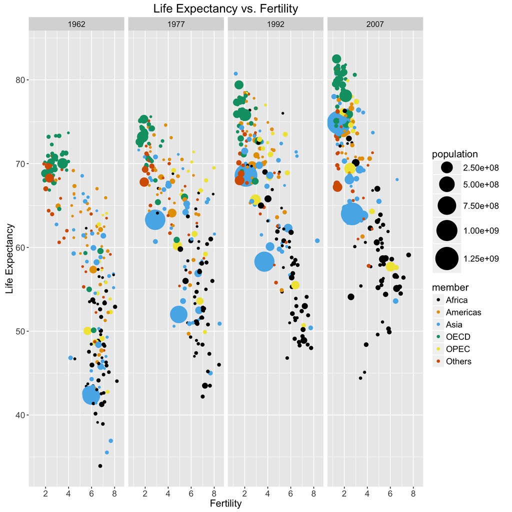

```r
c = seq(1962, 2007, 15)
p <- ggplot(filter(dat1, year%in%c), aes(x = fertility, y = life_expectancy))
p<- p + geom_point(aes(color = member, size = population)) +facet_grid(.~year)  +
    scale_size(range = c(1, 15))
p + geom_text_repel(data = filter(dat1, member =="none"),aes(label = continent))+theme(text = element_text(size=14),axis.text.x = element_text(size =12), axis.text.y = element_text(size =12),legend.text=element_text(size=12))+ggtitle("Life Expectancy vs. Fertility")+labs(x = "Fertility", y = "Life Expectancy")+scale_colour_manual(values=cbbPalette)
```

Would you say that the same dichotomy exists today? Explain:

Not that obvious now. The circles represent each country merged to the top left gradually in the past few decades. It can be that the health conditions have been improved globally so that the life expectancy among countries has increased over time. Also, more and more people have got chance to expose to knowledge of birth control and age of first marriage has also increased gradually among several countries.

## Problem 3.5 (Optional)

Make an animation with the `gganimate` package.

```
## Executing:
## 'convert' -loop 0 -delay 100 Rplot1.png Rplot2.png Rplot3.png
##     Rplot4.png Rplot5.png Rplot6.png Rplot7.png Rplot8.png
##     Rplot9.png Rplot10.png Rplot11.png 'animate.gif'
```

```
## Output at: animate.gif
```

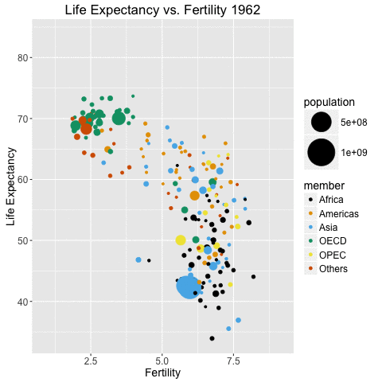

```r
library(gganimate)
c = seq(1962,2015,5)
p <- ggplot(filter(dat1,year%in%c), aes(x = fertility, y = life_expectancy,color = member, size = population, frame = year))+ geom_point() +scale_size(range = c(1,18))+theme(text = element_text(size=14),axis.text.x = element_text(size =12), axis.text.y = element_text(size =12),legend.text=element_text(size=12))+ggtitle("Life Expectancy vs. Fertility")+labs(x = "Fertility", y = "Life Expectancy")+scale_colour_manual(values=cbbPalette)
gg_animate(p, "animate.gif")
```

# Problem 4

Having time as a third dimension made it somewhat difficult to see specific country trends. Let’s now focus on specific countries.

## Problem 4.1

Let’s compare France and its former colony Tunisia. Make a plot of fertility versus year with color denoting the country. Do the same for life expecancy. How would you compare Tunisia’s improvement compared to France’s in the past 60 years? Hint: use `geom_line`

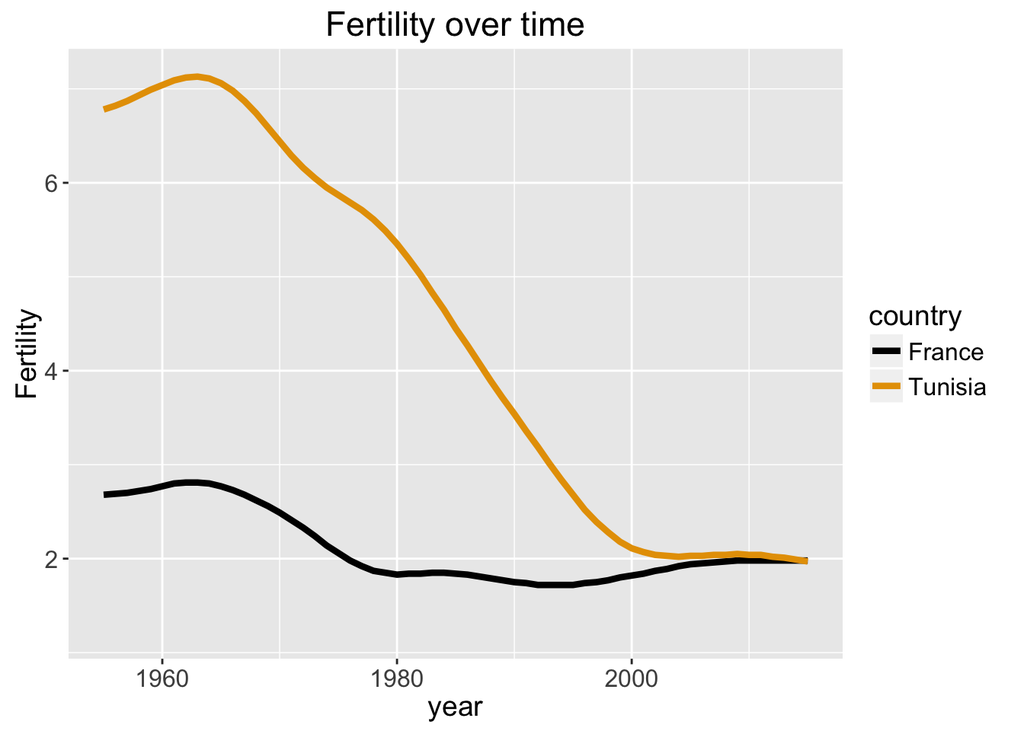

```r
p <- ggplot(filter(dat1, country == "France" | country == "Tunisia"), aes(x = as.numeric(year), y = fertility,group = country))+ geom_line(aes(color = country),size = 1.5)
p+scale_x_continuous("year",limits = c(1955, 2015))+theme(text = element_text(size=14),axis.text.x = element_text(size =12), axis.text.y = element_text(size =12),legend.text=element_text(size=12))+ggtitle("Fertility over time")+labs(y = "Fertility")+scale_colour_manual(values=cbbPalette)
```

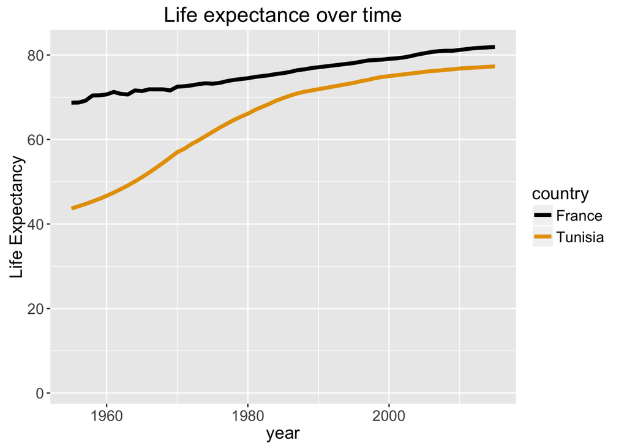

```r
p <- ggplot(filter(dat1, country == "France" | country == "Tunisia"), aes(x = as.numeric(year), y = life_expectancy,group = country))+ geom_line(aes(color = country),size = 1.5)
p+scale_x_continuous("year",limits = c(1955, 2015))+theme(text=element_text(size=14),axis.text.x = element_text(size =12), axis.text.y = element_text(size=12),legend.text=element_text(size=12))+ggtitle("Life expectance over time")+labs(y = "Life Expectancy")+scale_colour_manual(values=cbbPalette)
```

## Problem 4.2

Do the same, but this time compare Vietnam to the OECD countries.

```r
length(oecd)
```

```
## [1] 34
```

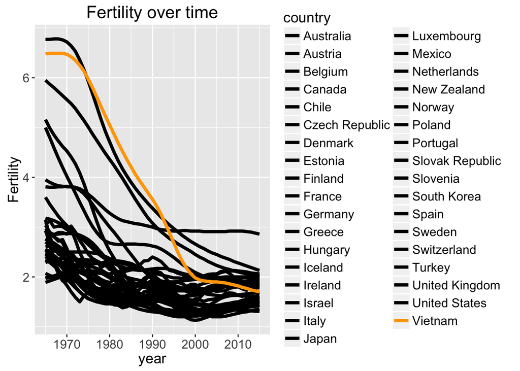

```r
cbb <-c(rep("black",34),"orange")
ggplot(filter(dat1, year %in% seq(1965,2015,1) & member == "OECD" |year %in% seq(1965,2015,1) & country == "Vietnam" ), aes(x = as.numeric(year), y = fertility))+ geom_line(aes(color = country),size = 1.5)+scale_x_continuous("year",limits = c(1965, 2015))+theme(text = element_text(size=14),axis.text.x = element_text(size =12), axis.text.y = element_text(size =12),legend.text=element_text(size=12))+ggtitle("Fertility over time")+labs(y = "Fertility")+scale_colour_manual(values=cbb)
```

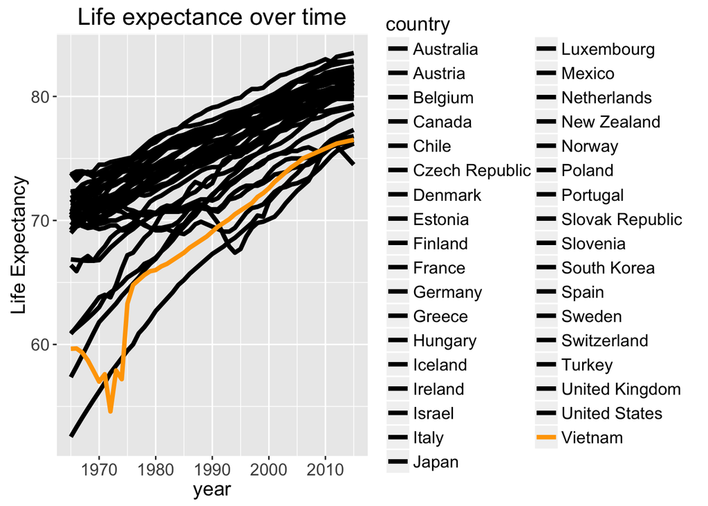

```r
ggplot(filter(dat1, year %in% seq(1965,2015,1) & member == "OECD" |year %in% seq(1965,2015,1) & country == "Vietnam" ), aes(x = as.numeric(year), y = life_expectancy))+ geom_line(aes(color = country),size = 1.5)+scale_x_continuous("year",limits = c(1965, 2015))+theme(text = element_text(size=14),axis.text.x = element_text(size =12), axis.text.y = element_text(size =12),legend.text=element_text(size=12))+ggtitle("Life expectance over time")+labs(y = "Life Expectancy")+scale_colour_manual(values=cbb)
```

I plotted all the OECD countries in black and Vietnam in orange. The fertility of Vietnam decreased (a lot) from 6+ to 1+ during the past 60 years and that of most OECD decreased but not that much (some OECD countries are still developing countries so have similar trend as Vietnam). The Life expectance of Vietnam increased by 15+ years during the past 60 years and that of most OECD countries increased by 5 - 10 years during the same period. Vietnam has improved more in terms of the abosolute change of the increasing life expectancy and the decreasing fertility rate compared to most OECD countries.

# Problem 5

We are now going to examine GDP per capita per day.

## Problem 5.1

Create a smooth density estimate of the distribution of GDP per capita per day across countries in 1970. Include OECD, OPEC, Asia, Africa, and the Americas in the computation. When doing this we want to weigh countries with larger populations more. We can do this using the “weight”" argument in `geom_density`.

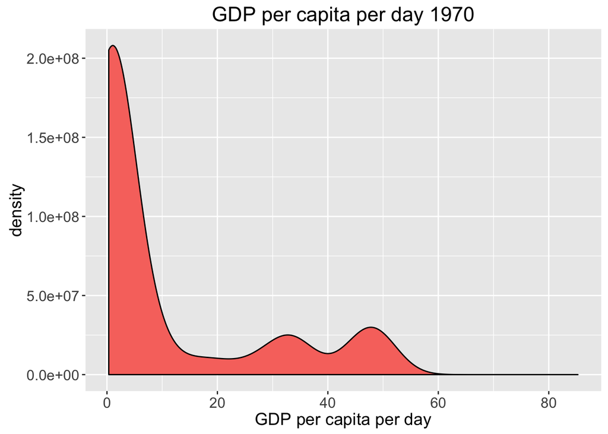

```r
dat1 <- mutate(dat1, gdp_capita_d = total_gdp/population/365)
p <- ggplot(filter(dat1, year == 1970 & (continent%in%c("Asia","Africa","Americas") | member%in%c("OECD","OPEC")) ), aes(gdp_capita_d))
p+ geom_density(aes(weight=population, fill = "orange"))+theme(text = element_text(size=14),axis.text.x = element_text(size =12), axis.text.y = element_text(size =12),legend.text=element_text(size=12))+ggtitle("GDP per capita per day 1970")+labs(x = "GDP per capita per day")+ guides(fill=FALSE)
```

## Problem 5.2

Now do the same but show each of the five groups separately.

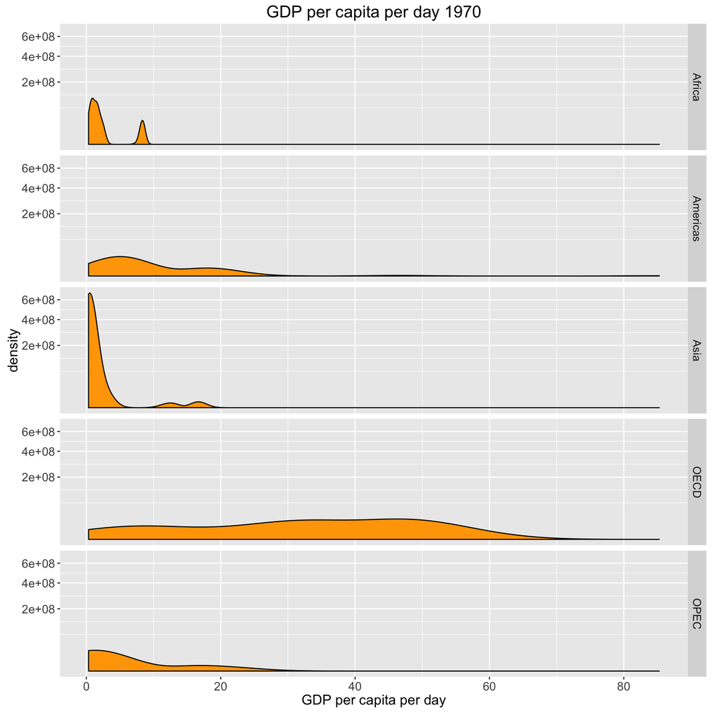

```r
# For countries in Americas, Asia and Africa, if they are in either OECD or OPEC, I categorize them as OECD or OPEC countries to avoid double counting in multiple graphs.

p <- ggplot(filter(dat1, year == 1970 & (member%in%c("OECD","OPEC","Americas","Asia","Africa"))), aes(gdp_capita_d))
p+ geom_density(aes(weight=population),fill = "orange")+facet_grid(member~.)+theme(text = element_text(size=14),axis.text.x = element_text(size =12), axis.text.y = element_text(size =12),legend.text=element_text(size=12))+ggtitle("GDP per capita per day 1970")+labs(x = "GDP per capita per day")+ guides(fill=FALSE) + scale_y_sqrt()
```

## Problem 5.3

Visualize these densities for several years. Show a couple of of them. Summarize how the distribution has changed through the years.

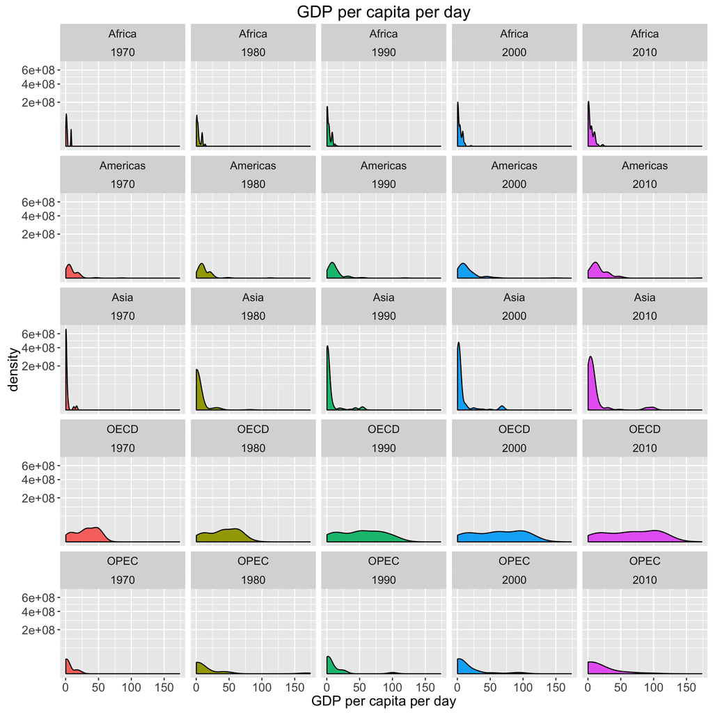

```r
p <- ggplot(filter(dat1, year%in% seq(1970,2010,10) & (member%in%c("OECD","OPEC","Americas","Asia","Africa"))), aes(gdp_capita_d))
p+ geom_density(aes(weight=population, fill = factor(year)))+facet_wrap(c("member","year"),nrow = 5)+theme(text = element_text(size=14),axis.text.x = element_text(size =12), axis.text.y = element_text(size =12),legend.text=element_text(size=12))+ggtitle("GDP per capita per day")+labs(x = "GDP per capita per day")+ guides(fill=FALSE) + scale_y_sqrt()
```

The variation of GDP per capita per day among OECD countries has increased more than other category of countries over the past 50 years, meaning that the economy of some OECD countries might have been left behind that of other OECD countries. Overall, OECD countries still have GDP per capita way greater than other parts of the world.